# Final Project

Puzhu Wang, Paul Zhang, Yilin Chen

2025-04-01

# SEIRS Model

## Model Specification

We propose a SEIRS (Susceptible - Exposed - Infectious - Recovered - Susceptible) Model, which is a compartmental epidemiological model that extends the classical SEIR model by including the transition from state $R$ to $S$, thus allowing re-infections.

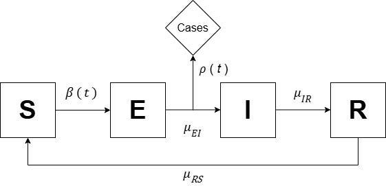

The model can be characterized by the following system of differential equations,

$$\begin{align*}
\frac{\mathrm{d}S}{\mathrm{d}t} &= -\mu_{SE} S(t) + \mu_{RS}
R(t) \\
\frac{\mathrm{d}E}{\mathrm{d}t} &= \mu_{SE} S(t) - \mu_{EI} E(t)
\\
\frac{\mathrm{d}I}{\mathrm{d}t} &= \mu_{EI} E(t) - \mu_{IR} I(t)
\\
\frac{\mathrm{d}R}{\mathrm{d}t} &= \mu_{IR} I(t) - \mu_{RS} R(t)
\\
\end{align*}$$

where

- $\mu_{SE} = \beta(t)$ is the transition rate from state $S$ to state $E$, also known as the *transmission rate*;
- $\mu_{EI}$ is the transition rate from state $E$ to state $I$;
- $\mu_{IR}$ is the transition rate from state $I$ to state $R$;
- $\mu_{RS}$ is the transition rate from state $R$ to state $S$;
- $N(t) = S(t) + E(t) + I(t) + R(t)$ is the population size, which is assumed to be constant throughout the epidemic.

In order to discretize the model, we assume that each transition between compartments is a *binomial* random variable, *i.e.*
$$\begin{align*}
\Delta N_{SE} &= Binomial(S, 1 - e^{-\beta(t) \frac{I \Delta t}{N}})
\\
\Delta N_{EI} &= Binomial(E, 1 - e^{-\mu_{EI} \Delta t}) \\
\Delta N_{IR} &= Binomial(I, 1 - e^{-\mu_{IR} \Delta t}) \\
\Delta N_{RS} &= Binomial(R, 1 - e^{-\mu_{RS} \Delta t}) \\
\end{align*}$$

As demonstrated in earlier sections, the sample period can be segmented into three distinct phases. Accordingly, we allow the transmission rate, $\beta(t)$, to vary across these phases to reflect changes in underlying epidemic dynamics. Specifically, let $\beta(t)$ be a piecewise function *s.t.*
$$\begin{equation*} \beta(t) =
\left\{
\begin{matrix}
b_1, & t \in [1, 61] \\
b_2, & t \in [62, 96] \\
b_3, & t \in [63, 119]
\end{matrix}
\right.\end{equation*}$$

Additionally, we assume a negative binomial distribution for the number of reported cases $Y(t)$ with fixed dispersion parameter $k$, *i.e.*
$$Y \sim NegBinom(\rho * H,
\rho * H + \frac{(\rho H)^2}{k})$$
where

- $\rho$ is the reporting rate
- $H$ is the number of total infections per week
- $k=10$ is the fixed parameter

Moreover, given the large population size in Kerala, the initial number of infected individuals was set to 1,000 to ensure that the first outbreak unfolds within a reasonable time frame.

## Why not SEIR

We do not start with the SEIR model since it assumes that recovered individuals gain *permanent* immunity, which is inconsistent with the multiple outbreaks we have observed in Kerala during the sample time interval.

Alternatively, we consider adding the $R \rightarrow S$ route in order to allow recovered individuals to lose immunity over time, return to the susceptible state, thus enabling re-infections. Without this transition, the SEIR model would eventually trap all individuals in $R$ forever with enough time, leading to unrealistic depletion of susceptibles and underestimation of future waves.

## SEIRS, with Time-varying $\beta$

We began our analysis with a SEIRS model featuring time-varying transmission rates across three epidemic phases, while initially holding the dispersion parameter $(k)$ and the reporting rate $(\rho)$ fixed. This setup captured changes in disease transmission but did not account for evolving uncertainty in reported case counts or shifts in surveillance quality.

### Initial Guesses

Moreover, $\eta$ is set to $0.1$ considering the large population size in Kerala. Large $N$ implies high absolute infection counts in spite of small proportions, which would possibly sufficient for the early seeding of the outbreaks.

Finally, we discovered that $\mu_{RS} = 0.005$ would be a biologically plausible value. Since the population is very large, while the cumulative number of infections remains relatively small, the proportion of individuals who have recovered (*i.e.*, entered the $R$ compartment) is also minimal. In such cases, the model is insensitive to the exact value of $\mu_{RS}$, meaning it may be safely fixed to a plausible value for improved model stability.

We continue by examing the particle filters and plotting the simulations based on our initial parameters:

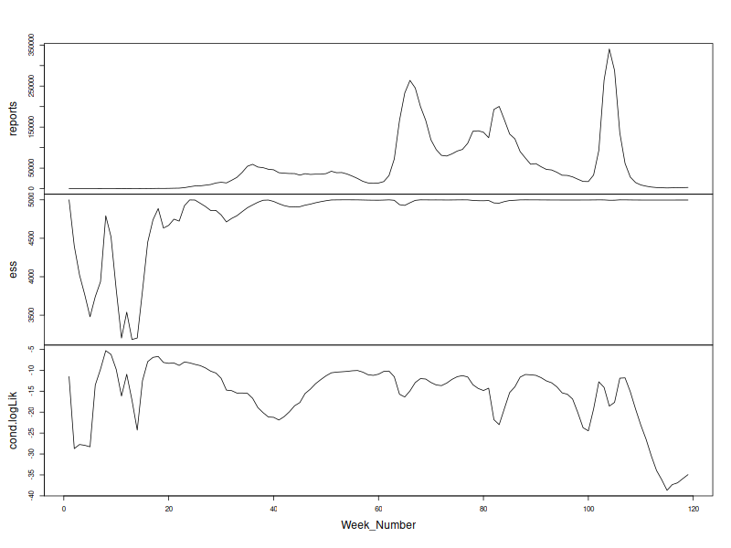

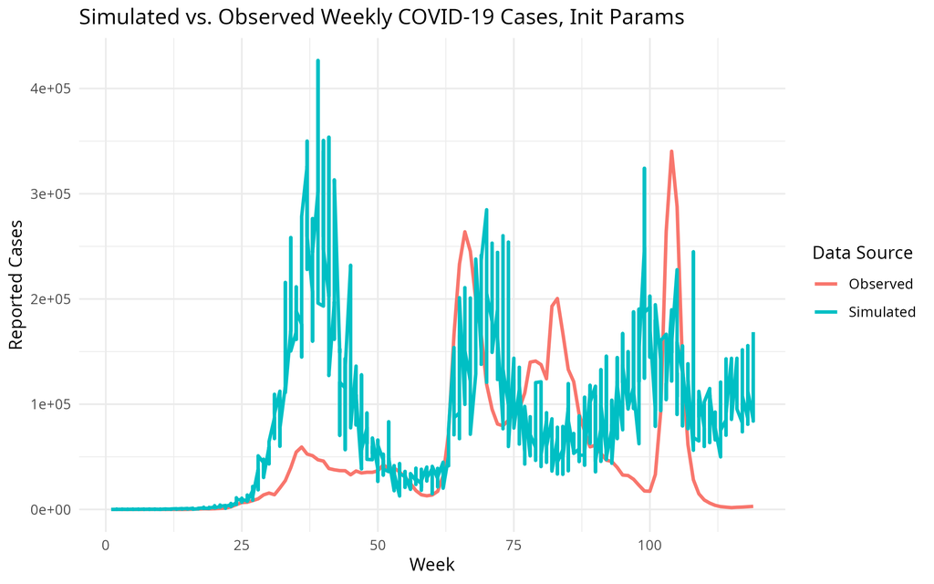

Our initial parameters have managed to capture the timeline of all three outbreaks, but failed to estimate the magnitudes.

## Local Search

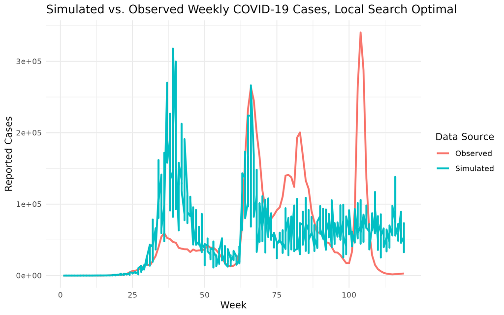

## SEIRS with Multi-stage Beta and K

### Model Modification

We modify our negative binomial distribution for the number of reported cases $Y(t)$ with time-varying dispersion, *i.e.*
$$Y
\sim NegBinom(\rho * H, \rho * H + \frac{(\rho H)^2}{k(t)})$$
where

- $\rho$ is the reporting rate
- $H$ is the number of total infections per week
- $k(t)$ is the interval-specific dispersion parameter which satisfies that
  $$\begin{equation*} k(t) = \left\{
  \begin{matrix}
  k_1, & t \in [1, 61] \\
  k_2, & t \in [62, 96] \\
  k_3, & t \in [63, 119]
  \end{matrix}
  \right.\end{equation*}$$

The initial guess is almost the same as the previous section, except that
$$k_1 = 8, k_2 = 5, k_3 = 1$$

Again, we need to check the particle filter and do the simulations.

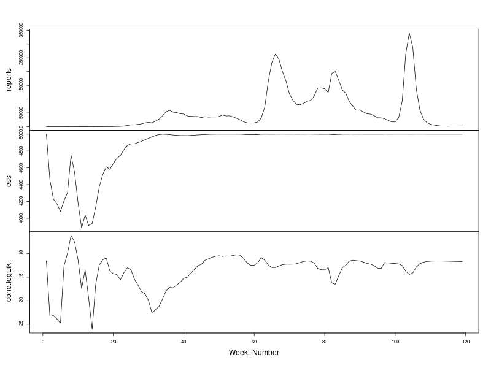

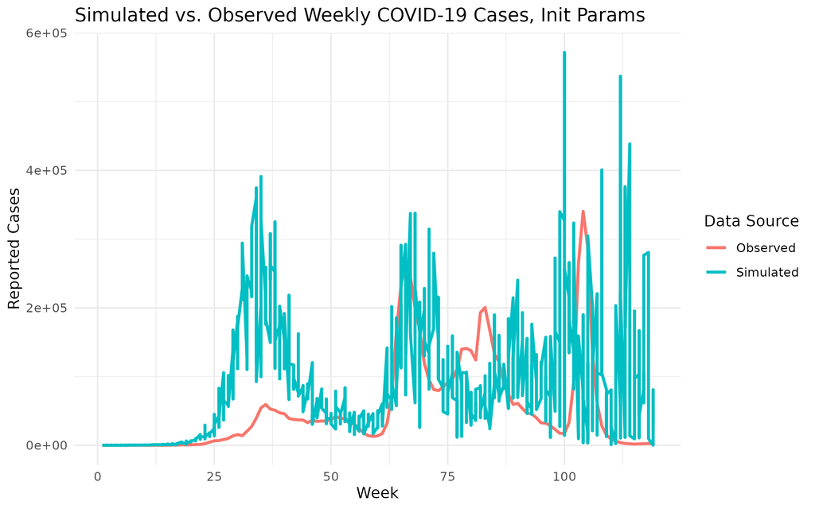

## Local Search

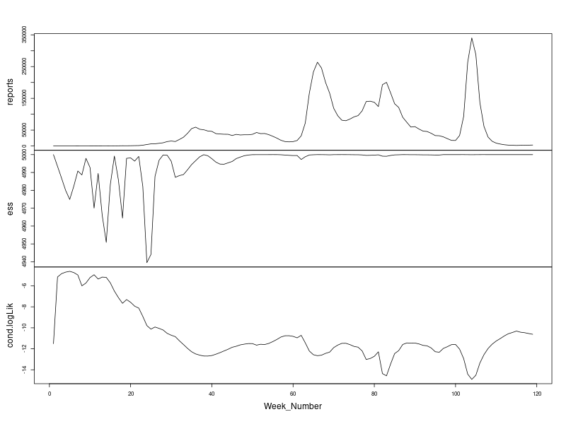

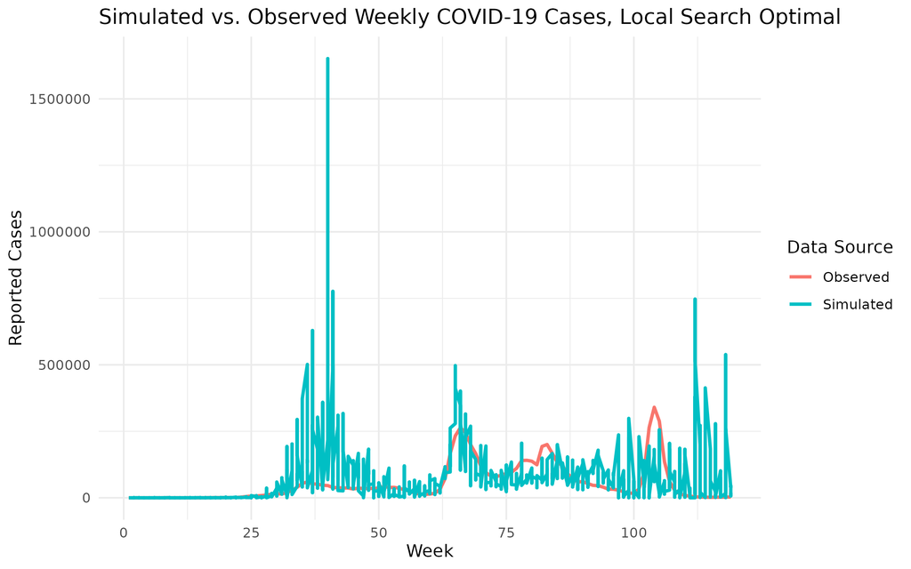

# SEIRS (Multi-stage Beta, K, Rho)

## Model Modification

We modify our negative binomial distribution for the number of reported cases $Y(t)$ with time-varying reporting rate and dispersion, *i.e.*
$$Y \sim NegBinom(\rho(t) * H, \rho(t) * H +
\frac{(\rho(t) H)^2}{k(t)})$$
where

- $\rho(t)$ is the interval-specific reporting rate which satisfies that
  $$\begin{equation*} k(t) = \left\{
  \begin{matrix}
  \rho_1, & t \in [1, 61] \\
  \rho_2, & t \in [62, 96] \\
  \rho_3, & t \in [63, 119]
  \end{matrix}\right.\end{equation*}$$
- $H$ is the number of total infections per week
- $k(t)$ is the interval-specific dispersion parameter which satisfies that
  $$\begin{equation*} k(t) = \left\{
  \begin{matrix}
  k_1, & t \in [1, 61] \\
  k_2, & t \in [62, 96] \\
  k_3, & t \in [63, 119]
  \end{matrix}
  \right.\end{equation*}$$

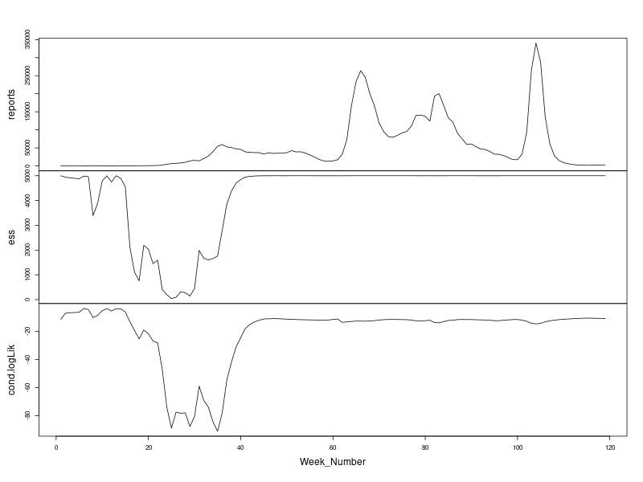

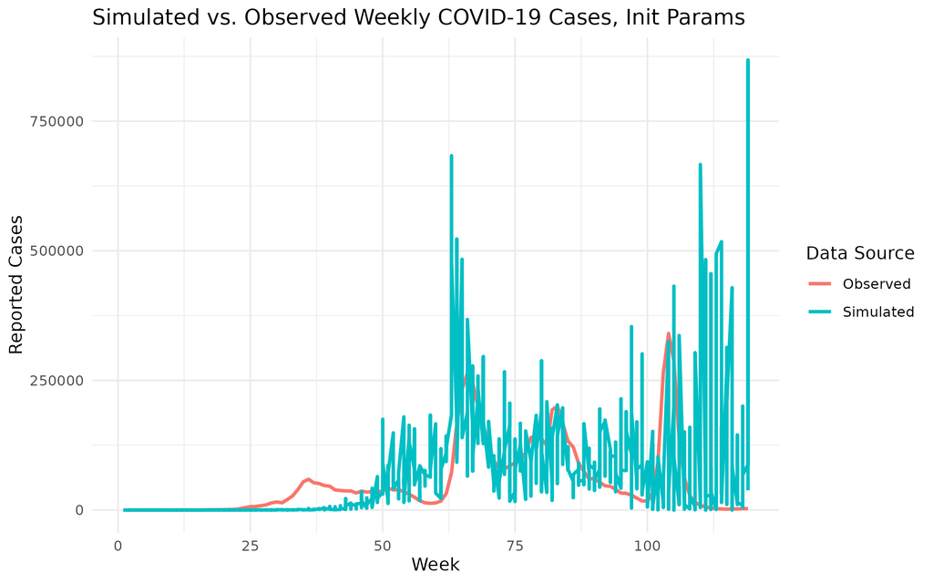

## Local Search

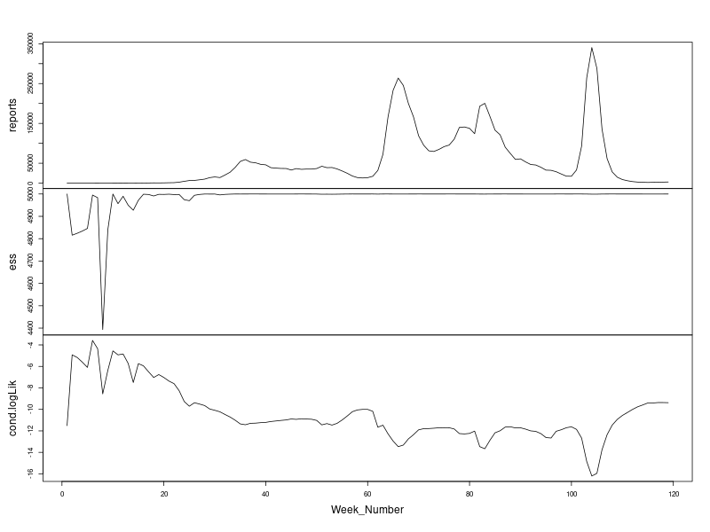

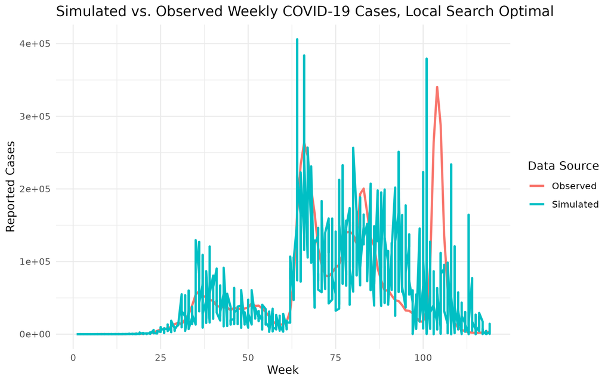

[^1]: Lauer, S. A., Grantz, K. H., Bi, Q., Jones, F. K., Zheng, Q., Meredith, H. R., Azman, A. S., Reich, N. G., & Lessler, J. (2020). The Incubation Period of Coronavirus Disease 2019 (COVID-19) From Publicly Reported Confirmed Cases: Estimation and Application. Annals of internal medicine, 172(9), 577–582. https://doi.org/10.7326/M20-0504